# l03-additional-info-geom_bar

In today’s lecture there was a question about what happens when we do not use stat=“Identity” in a geom_bar statement.

The code shown in lecture was using the infectious disease data in the Ch01_ID-data.csv dataset.

The plot for that looked like this:

```r
library(readr)
id_data <- read_csv("Ch01_ID-data.csv")
```

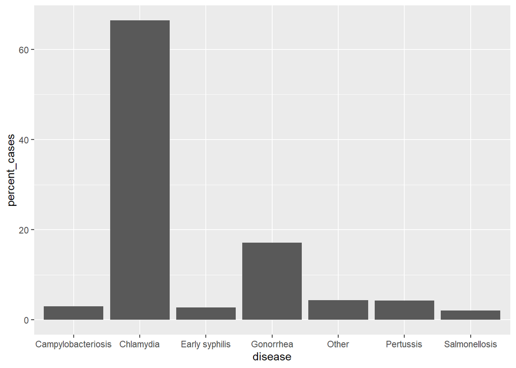

```r
library(ggplot2)
ggplot(id_data, aes(x = disease, y = percent_cases)) +
  geom_bar(stat="Identity")
```

the `stat="Identity" designation tells the geom_bar function that we want to over-ride the default setting and use the actual values stored in`percent_cases`to determine the height of the bars. If we do not add`stat=“Identity”` the code will not run:

You will get a message that says “Error: stat_count() can only have an x or y aesthetic.”

This is because the default for geom_bar is to take one X or Y variable and count the number of occurrences for that variable. If we try that with our x variable, notice what happens:

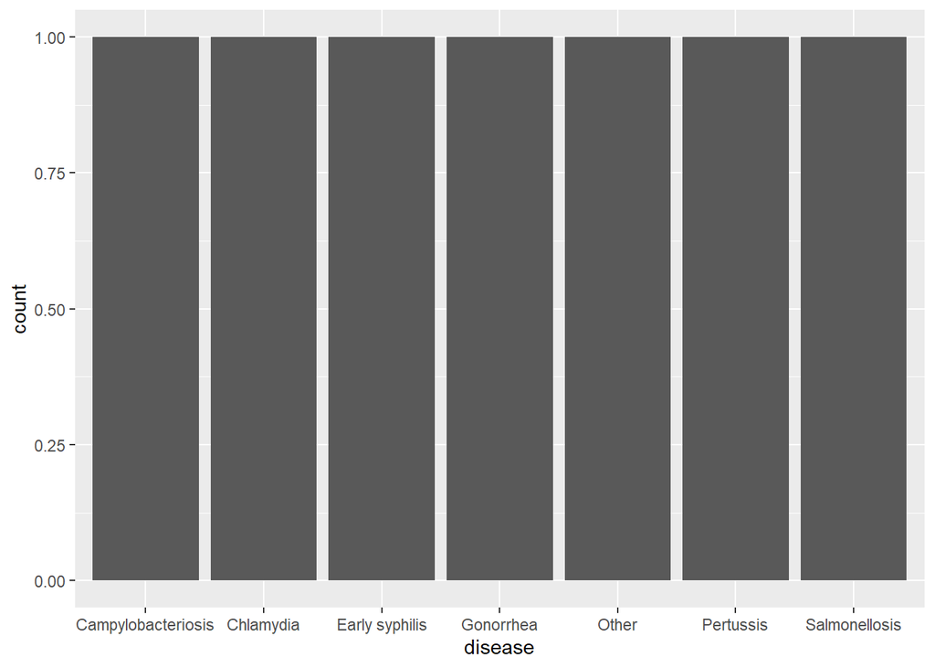

```r
ggplot(id_data, aes(x = disease)) +
  geom_bar()
```

This is because R has “counted” the number of times each value for the variable ‘disease’ shows up in the dataset.  
But remember the structure of our data frame:

```r
id_data
```

```
## # A tibble: 7 x 4
##   disease            type      number_cases percent_cases
##   <chr>              <chr>            <dbl>         <dbl>
## 1 Chlamydia          STI             174557         66.4
## 2 Gonorrhea          STI              44974         17.1
## 3 Pertussis          Pertussis        11219          4.27
## 4 Campylobacteriosis Foodborne         7919          3.01
## 5 Early syphilis     STI               7191          2.74
## 6 Salmonellosis      Foodborne         5361          2.04
## 7 Other              Other            11559          4.40
```

Each line in the dataset captures the aggregated data for that disease, so each value for the variable `disease` appears only one time in the dataset.

Likewise if we try to use geom_bar for `percent_cases` we get the following:

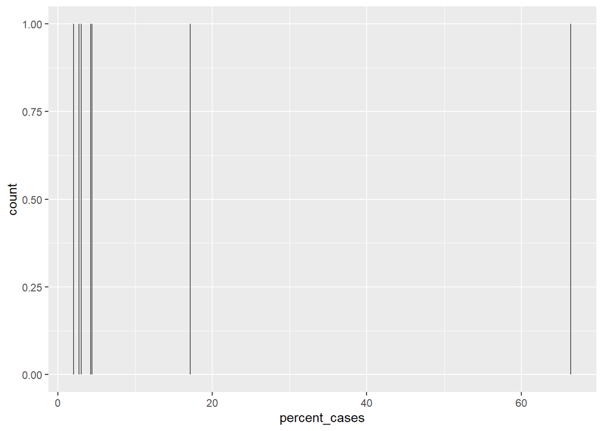

```r
ggplot(id_data, aes(percent_cases)) +
  geom_bar()
```

R is counting how many times each value for `percent_cases` appears in the data.

If we had a dataframe/dataset where each line/row represented one reported case of an infectious disease and we had a separate column indicating the disease then we might use the geom_bar() without stat=“Identity” to have R summarize for us the number of cases in each category.

For example, if I had this dataset:

```r
id_data_long <- read_csv("id_data_long.csv")
head(id_data_long)
```

```
## # A tibble: 6 x 3
##   Case_ID disease            type
##     <dbl> <chr>              <chr>
## 1       1 Campylobacteriosis Foodborne
## 2       2 Campylobacteriosis Foodborne
## 3       3 Campylobacteriosis Foodborne
## 4       4 Chlamydia          STI
## 5       5 Chlamydia          STI
## 6       6 Chlamydia          STI
```

```r
dim(id_data_long)
```

```
## [1] 100   3
```

Notice the structure of the data. Now, if I use geom_bar I would use the syntax without stat=“Identity” as follows:

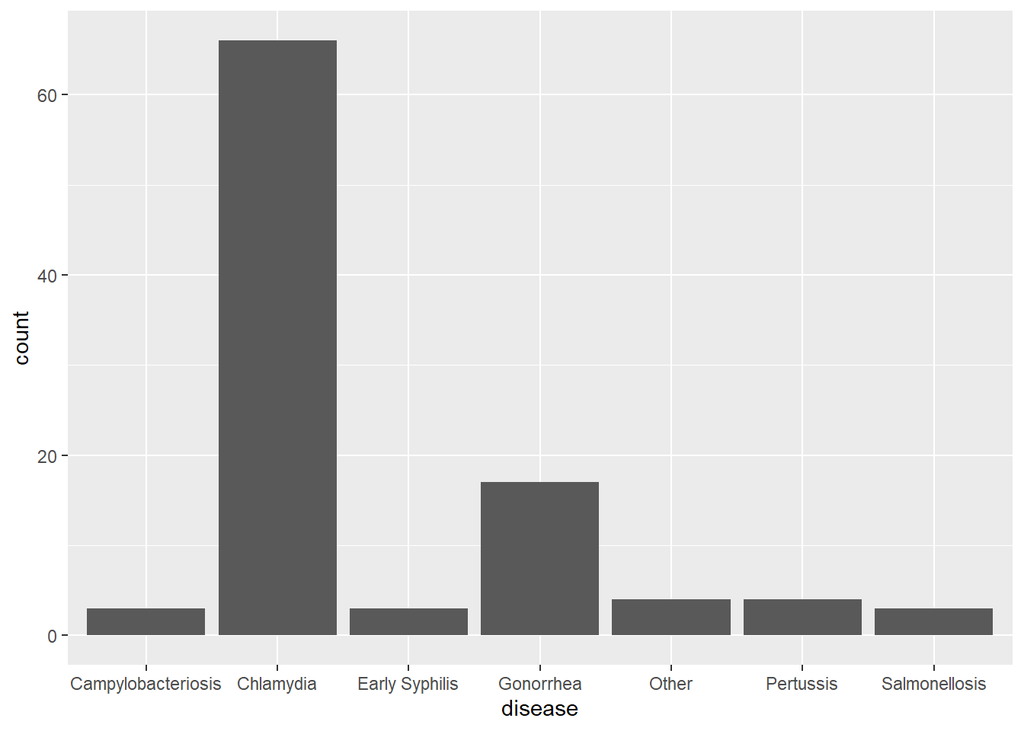

```r
ggplot(id_data_long, aes(x = disease)) +
  geom_bar()
```